# Sesjon 4: R som tegneprogram (base-R)

R-workshop 30. og 31. august, OsloMet

En av de to største årsakene til at er blitt så populært er muligheten for grafisk framstilling. R er et ypperlig tegneprogram. Det hele skjøt enda mer fart da `ggplot2`-pakken ble lansert. Den er basert på noe anderledes gramatikk. Idag ser vi på base-R slik at dere blir vant til å tenke i koordinatsystem. I morgen tar vi en titt på ggplot2.

- hvordan plassere punkter og linjer i et koordinatsystem på enklest mulig vis ved hjelp av `plot()`-funksjonen.
- hvordan legge informasjon til et allerede eksisterende koordinatsystem og gi en god tegnforklaring.

# Plassere punkter i et koordinatsystem

Samtlige grafikker baserer seg på informasjon som legges inn i et koordinatsystem. Vi har en x-akse (den horisontale linjen) og en y-akse (den vertikale linjen). Når vi tegner, oppgir vi punkter som har en x-verdi og en y-verdi. Det vil si at vi oppgir koordinatene.

For å opprette et tegneark, bruker vi `plot()`

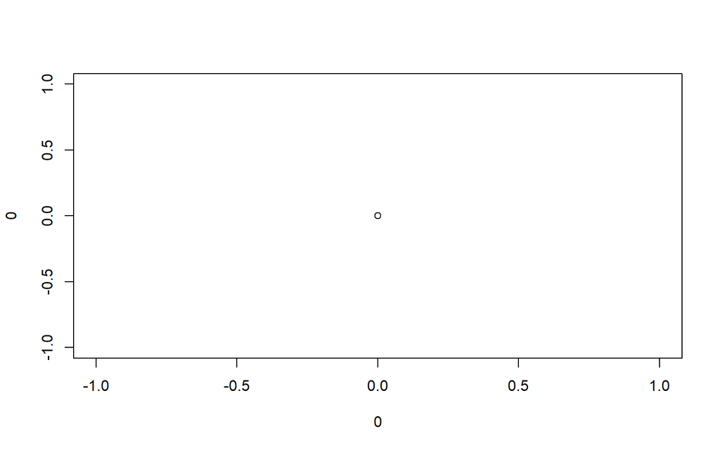

```r
plot(x=0, y=0)
```

Vi kan tegne flere punkter samtidig ved å opprette vektorer for x- og y-verdiene.

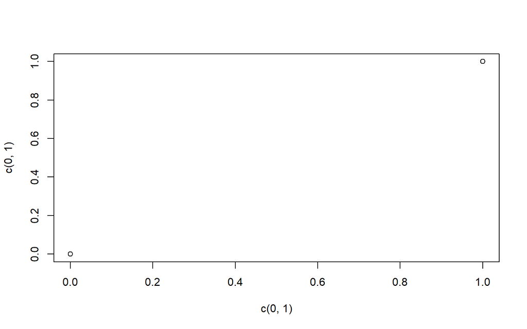

```r
plot(x=c(0,1), y=c(0,1))
```

Vi kan trekke linje mellom to punkter.

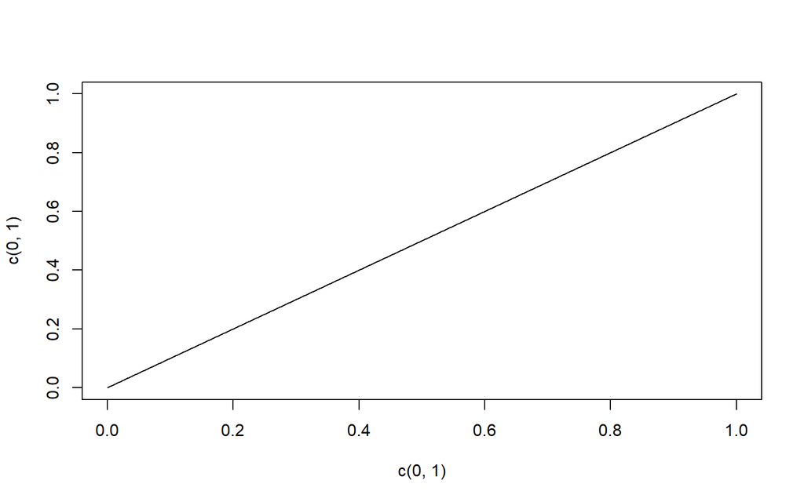

```r
plot(x=c(0,1), y=c(0,1), type = "l")
```

… eller tre.

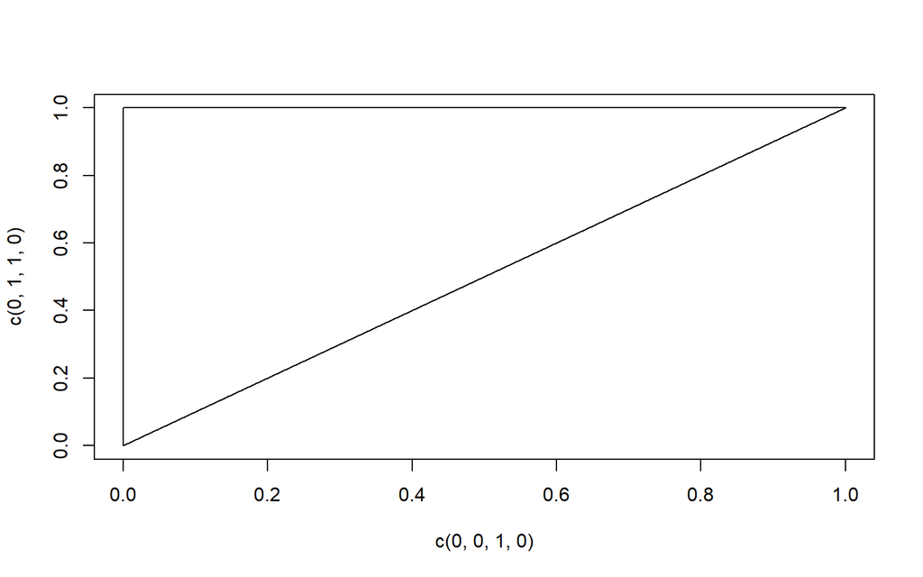

```r
plot(x = c(0,0,1,0),
       y = c(0,1,1,0),
       type = "l")
```

# Opprette tegneark for så å legge inn informasjon

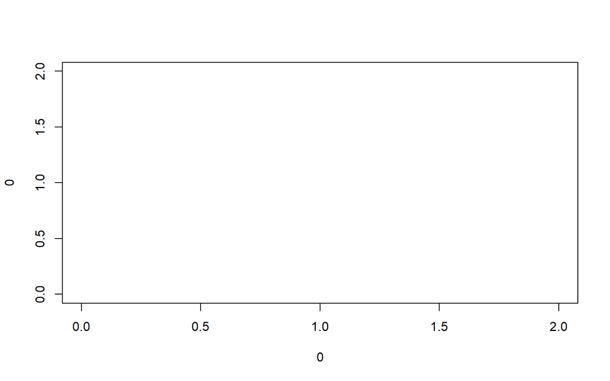

```r
  plot(x = 0,
       y = 0,
       type = "n",
       xlim = c(0,2),
       ylim = c(0,2))
```

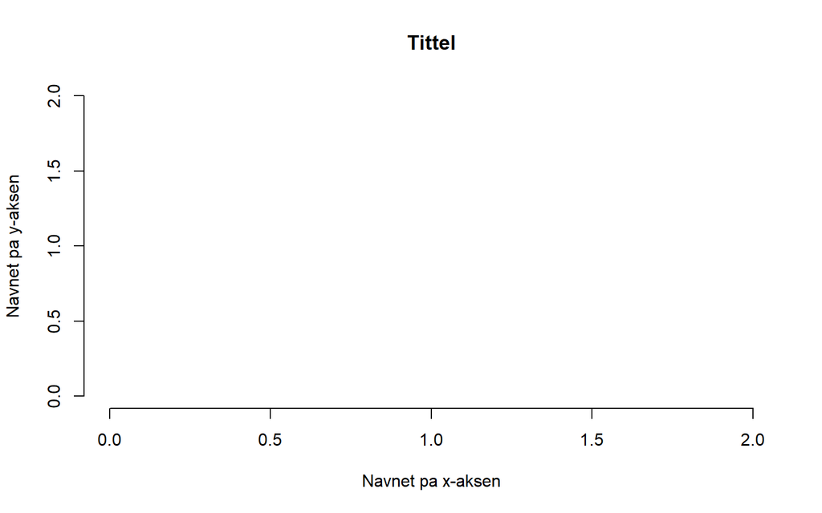

```r
 plot(x = 0,
       y = 0,
       type = "n",
       xlim = c(0,2),
       ylim = c(0,2),
       main = "Tittel",
       xlab = "Navnet pa x-aksen",
       ylab = "Navnet pa y-aksen",
       bty = "n")
```

## Legge til grafikk på eksisterende ark

Vi kan legge til tegnforklaringer, punkter, linjer, tekst, segmenter, piler og polygoner/former.

### Legge til punkter, linjer og tekst

Når arket allerede er opprettet ved hjelp av `plot()` `plot()`-funksjonen, kan vi legge til elementer.

Punkter

```r
points(x = c(0,1),
         y = c(0,1),
         pch = 16)
```

```r
lines(x = c(0,1,2),
      y = c(0,1,1),
      lty = 2)
```

```r
text(x = c(0,1,2),
       y = c(0,1,1),
       labels = c("Lav", "Hoy", "Ogsa hoy"))
```

| Funksjon | Argument | R-funk. | R-arg. |
| --- | --- | --- | --- |
| Plot |  | plot() |  |
| (basisfunksjon for grafikk) |  |  |  |
|  | x-koordinatene |  | x= |
|  | y-koordinatene |  | y= |
|  | type grafikk: Linje (‘l’), punkter(‘p’), |  | type= |
|  | begge deler (‘b’), histogram (‘h’), |  |  |
|  | ingen liner (‘n’) |  |  |
|  | farge (kan oppgis i tall eller ‘ord’) |  | col= |
|  | start- og sluttpunkt pa x-aksen (oppgis som vektor) |  | xlim= |
|  | start- og sluttpunkt pa y-aksen (oppgis som vektor) |  | ylim= |
|  | navn pa x-aksen (oppgis i ‘hermetegn’) |  | xlab= |
|  | navn pa y-aksen (oppgis i ‘hermetegn’) |  | ylab= |
|  | overskrift (oppgis i ‘hermetegn’) |  | main= |
|  | bokstype rundt plottet: ingen boks (‘n’) |  | bty= |
| Legg linje til i |  | lines() |  |
| eksisterende grafikk |  |  |  |
|  | x-koordinatene |  | x= |
|  | y-koordinatene |  | y= |
|  | type line (oppgis i tall) |  | lty= |
|  | tykkelse pa linje (oppgis i tall) |  | lwd= |
| Legg punkter til i |  | points() |  |
| eksisterende grafikk |  |  |  |
|  | x-koordinatene |  | x= |
|  | y-koordinatene |  | y= |
|  | type punkt (oppgis i tall) |  | pch= |
|  | storrelse pa punkter (oppgis i tall) |  | cex= |
| Legg punkter til i |  | text() |  |
| eksisterende grafikk |  |  |  |
| i form av tekst |  |  |  |
|  | x-koordinatene |  | x= |
|  | y-koordinatene |  | y= |
|  | tekst (oppgis i hermetegn) |  | labels= |
|  | storrelse pa tekst (oppgis i tall) |  | cex= |
| Legg piler til i |  | arrows() |  |
| eksisterende grafikk |  |  |  |
|  | x-koordinaten for starten pa pilen |  | x0= |
|  | y-koordinaten for starten pa pilen |  | y0= |
|  | x-koordinaten for pilspissen |  | x1= |
|  | y-koordinaten for pilspissen |  | y1= |
| Tegnforklaring |  | legend() |  |
| (boks plassert i grafikk) |  |  |  |
|  | x-koordinat for plassering |  | x= |
|  | y-koordinat for plassering |  | y= |
|  | forklarende tekst (vektor) |  | legend= |
|  | linjetyper (lik rekkefolge som foregaende) |  | lty= |
|  | punkttyper (lik rekkefolge som foregaende) |  | pch= |
|  | farger (lik rekkefolge som foregaende) |  | col= |

## Farger og størrelser

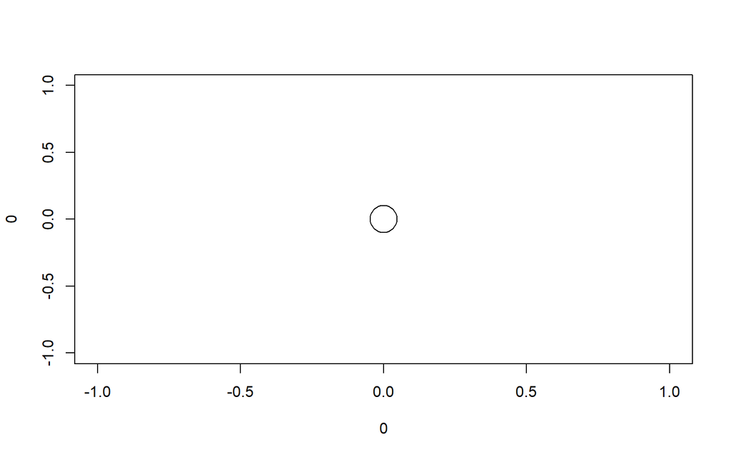

```r
  plot(x=0, y=0, cex=4)
```

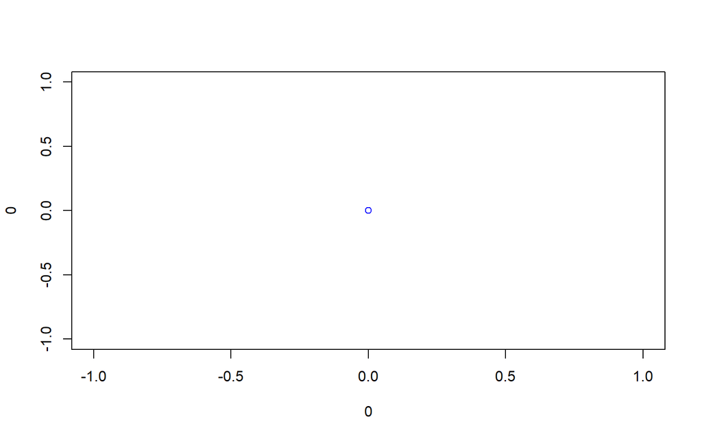

```r
  plot(x=0, y=0, col="blue")
```

Fargene kan også være en vektor

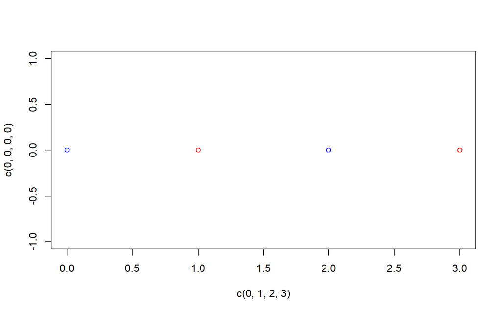

```r
plot(x=c(0,1,2,3),
       y=c(0,0,0,0),
       col=c("blue", "red"))
```

**Tegnforklaringer**

```r
legend(x="topright",
         legend = c("Blå", "Rød"),
         pch = 1,
         col = c("blue", "red"))
```

## Din tur!

Opprett data

```r
parti<-c("Ap", "FrP", "H", "KrF", "MDG", "Sp","SV", "V")
hoyre<-c(3.75, 7.5, 7.25, 6, 2.25, 4, 1.5, 6.75)
omfordeling<-c(5.33, 4, 3.33, 4, 5.33, 4.67, 5.33, 3.33)
viktighet<-c(6.67, 5.67, 7.33, 4.33, 3.33, 5.33, 5.67, 5.67)
df<-data.frame(parti, hoyre, omfordeling, viktighet)
```

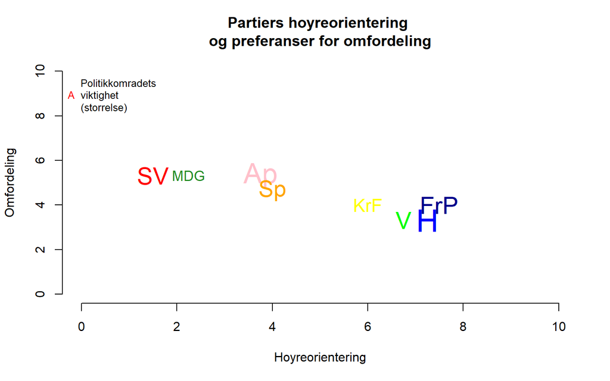